# Risk Factor Analysis

## Outcome Variable

**Outcome Variable:** ever_wasted

## Predictor Variables

**Intervention Variable:** born_wasted

**Adjustment Set:**

unadjusted

## Stratifying Variables

The analysis was stratified on these variable(s):

- agecat
- studyid
- country

## Data Summary

| agecat | studyid | country | born_wasted | ever_wasted | n_cell | n |
| --- | --- | --- | --- | --- | --- | --- |
| 0-3 months | ki0047075b-MAL-ED | BANGLADESH | 0 | 0 | 195 | 244 |
| 0-3 months | ki0047075b-MAL-ED | BANGLADESH | 0 | 1 | 9 | 244 |
| 0-3 months | ki0047075b-MAL-ED | BANGLADESH | 1 | 0 | 40 | 244 |
| 0-3 months | ki0047075b-MAL-ED | BANGLADESH | 1 | 1 | 0 | 244 |
| 0-3 months | ki0047075b-MAL-ED | BRAZIL | 0 | 0 | 171 | 183 |
| 0-3 months | ki0047075b-MAL-ED | BRAZIL | 0 | 1 | 6 | 183 |
| 0-3 months | ki0047075b-MAL-ED | BRAZIL | 1 | 0 | 6 | 183 |
| 0-3 months | ki0047075b-MAL-ED | BRAZIL | 1 | 1 | 0 | 183 |
| 0-3 months | ki0047075b-MAL-ED | INDIA | 0 | 0 | 149 | 204 |
| 0-3 months | ki0047075b-MAL-ED | INDIA | 0 | 1 | 21 | 204 |
| 0-3 months | ki0047075b-MAL-ED | INDIA | 1 | 0 | 34 | 204 |
| 0-3 months | ki0047075b-MAL-ED | INDIA | 1 | 1 | 0 | 204 |
| 0-3 months | ki0047075b-MAL-ED | NEPAL | 0 | 0 | 143 | 168 |
| 0-3 months | ki0047075b-MAL-ED | NEPAL | 0 | 1 | 5 | 168 |
| 0-3 months | ki0047075b-MAL-ED | NEPAL | 1 | 0 | 20 | 168 |
| 0-3 months | ki0047075b-MAL-ED | NEPAL | 1 | 1 | 0 | 168 |
| 0-3 months | ki0047075b-MAL-ED | PERU | 0 | 0 | 274 | 282 |
| 0-3 months | ki0047075b-MAL-ED | PERU | 0 | 1 | 2 | 282 |
| 0-3 months | ki0047075b-MAL-ED | PERU | 1 | 0 | 6 | 282 |
| 0-3 months | ki0047075b-MAL-ED | PERU | 1 | 1 | 0 | 282 |
| 0-3 months | ki0047075b-MAL-ED | SOUTH AFRICA | 0 | 0 | 234 | 258 |
| 0-3 months | ki0047075b-MAL-ED | SOUTH AFRICA | 0 | 1 | 6 | 258 |
| 0-3 months | ki0047075b-MAL-ED | SOUTH AFRICA | 1 | 0 | 18 | 258 |
| 0-3 months | ki0047075b-MAL-ED | SOUTH AFRICA | 1 | 1 | 0 | 258 |
| 0-3 months | ki0047075b-MAL-ED | TANZANIA, UNITED REPUBLIC OF | 0 | 0 | 142 | 145 |
| 0-3 months | ki0047075b-MAL-ED | TANZANIA, UNITED REPUBLIC OF | 0 | 1 | 1 | 145 |
| 0-3 months | ki0047075b-MAL-ED | TANZANIA, UNITED REPUBLIC OF | 1 | 0 | 2 | 145 |
| 0-3 months | ki0047075b-MAL-ED | TANZANIA, UNITED REPUBLIC OF | 1 | 1 | 0 | 145 |
| 0-3 months | ki1000108-CMC-V-BCS-2002 | INDIA | 0 | 0 | 42 | 88 |
| 0-3 months | ki1000108-CMC-V-BCS-2002 | INDIA | 0 | 1 | 32 | 88 |

[output cut: 410 more lines]

The following strata were considered:

- agecat: 0-3 months, studyid: ki0047075b-MAL-ED, country: BANGLADESH
- agecat: 0-3 months, studyid: ki0047075b-MAL-ED, country: BRAZIL
- agecat: 0-3 months, studyid: ki0047075b-MAL-ED, country: INDIA
- agecat: 0-3 months, studyid: ki0047075b-MAL-ED, country: NEPAL
- agecat: 0-3 months, studyid: ki0047075b-MAL-ED, country: PERU
- agecat: 0-3 months, studyid: ki0047075b-MAL-ED, country: SOUTH AFRICA
- agecat: 0-3 months, studyid: ki0047075b-MAL-ED, country: TANZANIA, UNITED REPUBLIC OF
- agecat: 0-3 months, studyid: ki1000108-CMC-V-BCS-2002, country: INDIA
- agecat: 0-3 months, studyid: ki1000108-IRC, country: INDIA
- agecat: 0-3 months, studyid: ki1000109-EE, country: PAKISTAN
- agecat: 0-3 months, studyid: ki1000109-ResPak, country: PAKISTAN
- agecat: 0-3 months, studyid: ki1000304b-SAS-CompFeed, country: INDIA
- agecat: 0-3 months, studyid: ki1017093-NIH-Birth, country: BANGLADESH
- agecat: 0-3 months, studyid: ki1017093b-PROVIDE, country: BANGLADESH
- agecat: 0-3 months, studyid: ki1017093c-NIH-Crypto, country: BANGLADESH
- agecat: 0-3 months, studyid: ki1101329-Keneba, country: GAMBIA
- agecat: 0-3 months, studyid: ki1114097-CMIN, country: BANGLADESH
- agecat: 0-3 months, studyid: ki1114097-CMIN, country: BRAZIL
- agecat: 0-3 months, studyid: ki1114097-CMIN, country: GUINEA-BISSAU
- agecat: 0-3 months, studyid: ki1114097-CMIN, country: PERU
- agecat: 0-3 months, studyid: ki1114097-CONTENT, country: PERU
- agecat: 0-3 months, studyid: ki1119695-PROBIT, country: BELARUS
- agecat: 0-3 months, studyid: ki1126311-ZVITAMBO, country: ZIMBABWE
- agecat: 0-3 months, studyid: ki1135781-COHORTS, country: GUATEMALA
- agecat: 0-3 months, studyid: ki1135781-COHORTS, country: INDIA
- agecat: 0-3 months, studyid: ki1135781-COHORTS, country: PHILIPPINES
- agecat: 0-3 months, studyid: kiGH5241-JiVitA-3, country: BANGLADESH
- agecat: 0-3 months, studyid: kiGH5241-JiVitA-4, country: BANGLADESH
- agecat: 12-24 months, studyid: ki0047075b-MAL-ED, country: BANGLADESH
- agecat: 12-24 months, studyid: ki0047075b-MAL-ED, country: BRAZIL
- agecat: 12-24 months, studyid: ki0047075b-MAL-ED, country: INDIA
- agecat: 12-24 months, studyid: ki0047075b-MAL-ED, country: NEPAL
- agecat: 12-24 months, studyid: ki0047075b-MAL-ED, country: PERU
- agecat: 12-24 months, studyid: ki0047075b-MAL-ED, country: SOUTH AFRICA
- agecat: 12-24 months, studyid: ki0047075b-MAL-ED, country: TANZANIA, UNITED REPUBLIC OF
- agecat: 12-24 months, studyid: ki1000108-CMC-V-BCS-2002, country: INDIA
- agecat: 12-24 months, studyid: ki1000108-IRC, country: INDIA
- agecat: 12-24 months, studyid: ki1000109-EE, country: PAKISTAN
- agecat: 12-24 months, studyid: ki1000109-ResPak, country: PAKISTAN
- agecat: 12-24 months, studyid: ki1000304b-SAS-CompFeed, country: INDIA
- agecat: 12-24 months, studyid: ki1017093-NIH-Birth, country: BANGLADESH
- agecat: 12-24 months, studyid: ki1017093b-PROVIDE, country: BANGLADESH
- agecat: 12-24 months, studyid: ki1017093c-NIH-Crypto, country: BANGLADESH
- agecat: 12-24 months, studyid: ki1101329-Keneba, country: GAMBIA
- agecat: 12-24 months, studyid: ki1114097-CMIN, country: BANGLADESH
- agecat: 12-24 months, studyid: ki1114097-CMIN, country: BRAZIL
- agecat: 12-24 months, studyid: ki1114097-CMIN, country: GUINEA-BISSAU
- agecat: 12-24 months, studyid: ki1114097-CMIN, country: PERU
- agecat: 12-24 months, studyid: ki1114097-CONTENT, country: PERU
- agecat: 12-24 months, studyid: ki1119695-PROBIT, country: BELARUS
- agecat: 12-24 months, studyid: ki1126311-ZVITAMBO, country: ZIMBABWE
- agecat: 12-24 months, studyid: ki1135781-COHORTS, country: GUATEMALA
- agecat: 12-24 months, studyid: ki1135781-COHORTS, country: PHILIPPINES
- agecat: 12-24 months, studyid: kiGH5241-JiVitA-3, country: BANGLADESH
- agecat: 12-24 months, studyid: kiGH5241-JiVitA-4, country: BANGLADESH
- agecat: 3-6 months, studyid: ki0047075b-MAL-ED, country: BANGLADESH
- agecat: 3-6 months, studyid: ki0047075b-MAL-ED, country: BRAZIL
- agecat: 3-6 months, studyid: ki0047075b-MAL-ED, country: INDIA
- agecat: 3-6 months, studyid: ki0047075b-MAL-ED, country: NEPAL
- agecat: 3-6 months, studyid: ki0047075b-MAL-ED, country: PERU
- agecat: 3-6 months, studyid: ki0047075b-MAL-ED, country: SOUTH AFRICA
- agecat: 3-6 months, studyid: ki0047075b-MAL-ED, country: TANZANIA, UNITED REPUBLIC OF
- agecat: 3-6 months, studyid: ki1000108-CMC-V-BCS-2002, country: INDIA
- agecat: 3-6 months, studyid: ki1000108-IRC, country: INDIA
- agecat: 3-6 months, studyid: ki1000109-EE, country: PAKISTAN
- agecat: 3-6 months, studyid: ki1000109-ResPak, country: PAKISTAN
- agecat: 3-6 months, studyid: ki1000304b-SAS-CompFeed, country: INDIA
- agecat: 3-6 months, studyid: ki1017093-NIH-Birth, country: BANGLADESH
- agecat: 3-6 months, studyid: ki1017093b-PROVIDE, country: BANGLADESH
- agecat: 3-6 months, studyid: ki1017093c-NIH-Crypto, country: BANGLADESH
- agecat: 3-6 months, studyid: ki1101329-Keneba, country: GAMBIA
- agecat: 3-6 months, studyid: ki1114097-CMIN, country: BANGLADESH
- agecat: 3-6 months, studyid: ki1114097-CMIN, country: BRAZIL
- agecat: 3-6 months, studyid: ki1114097-CMIN, country: GUINEA-BISSAU
- agecat: 3-6 months, studyid: ki1114097-CMIN, country: PERU
- agecat: 3-6 months, studyid: ki1114097-CONTENT, country: PERU
- agecat: 3-6 months, studyid: ki1119695-PROBIT, country: BELARUS
- agecat: 3-6 months, studyid: ki1126311-ZVITAMBO, country: ZIMBABWE
- agecat: 3-6 months, studyid: ki1135781-COHORTS, country: GUATEMALA
- agecat: 3-6 months, studyid: ki1135781-COHORTS, country: PHILIPPINES
- agecat: 3-6 months, studyid: kiGH5241-JiVitA-3, country: BANGLADESH
- agecat: 3-6 months, studyid: kiGH5241-JiVitA-4, country: BANGLADESH
- agecat: 6-12 months, studyid: ki0047075b-MAL-ED, country: BANGLADESH
- agecat: 6-12 months, studyid: ki0047075b-MAL-ED, country: BRAZIL
- agecat: 6-12 months, studyid: ki0047075b-MAL-ED, country: INDIA
- agecat: 6-12 months, studyid: ki0047075b-MAL-ED, country: NEPAL
- agecat: 6-12 months, studyid: ki0047075b-MAL-ED, country: PERU
- agecat: 6-12 months, studyid: ki0047075b-MAL-ED, country: SOUTH AFRICA
- agecat: 6-12 months, studyid: ki0047075b-MAL-ED, country: TANZANIA, UNITED REPUBLIC OF
- agecat: 6-12 months, studyid: ki1000108-CMC-V-BCS-2002, country: INDIA
- agecat: 6-12 months, studyid: ki1000108-IRC, country: INDIA
- agecat: 6-12 months, studyid: ki1000109-EE, country: PAKISTAN
- agecat: 6-12 months, studyid: ki1000109-ResPak, country: PAKISTAN
- agecat: 6-12 months, studyid: ki1000304b-SAS-CompFeed, country: INDIA
- agecat: 6-12 months, studyid: ki1017093-NIH-Birth, country: BANGLADESH
- agecat: 6-12 months, studyid: ki1017093b-PROVIDE, country: BANGLADESH
- agecat: 6-12 months, studyid: ki1017093c-NIH-Crypto, country: BANGLADESH
- agecat: 6-12 months, studyid: ki1101329-Keneba, country: GAMBIA
- agecat: 6-12 months, studyid: ki1114097-CMIN, country: BANGLADESH
- agecat: 6-12 months, studyid: ki1114097-CMIN, country: BRAZIL
- agecat: 6-12 months, studyid: ki1114097-CMIN, country: GUINEA-BISSAU
- agecat: 6-12 months, studyid: ki1114097-CMIN, country: PERU
- agecat: 6-12 months, studyid: ki1114097-CONTENT, country: PERU
- agecat: 6-12 months, studyid: ki1119695-PROBIT, country: BELARUS
- agecat: 6-12 months, studyid: ki1126311-ZVITAMBO, country: ZIMBABWE
- agecat: 6-12 months, studyid: ki1135781-COHORTS, country: GUATEMALA
- agecat: 6-12 months, studyid: ki1135781-COHORTS, country: INDIA
- agecat: 6-12 months, studyid: ki1135781-COHORTS, country: PHILIPPINES
- agecat: 6-12 months, studyid: kiGH5241-JiVitA-3, country: BANGLADESH
- agecat: 6-12 months, studyid: kiGH5241-JiVitA-4, country: BANGLADESH

### Dropped Strata

Some strata were dropped due to rare outcomes:

- agecat: 0-3 months, studyid: ki0047075b-MAL-ED, country: BANGLADESH
- agecat: 0-3 months, studyid: ki0047075b-MAL-ED, country: BRAZIL
- agecat: 0-3 months, studyid: ki0047075b-MAL-ED, country: INDIA
- agecat: 0-3 months, studyid: ki0047075b-MAL-ED, country: NEPAL
- agecat: 0-3 months, studyid: ki0047075b-MAL-ED, country: PERU
- agecat: 0-3 months, studyid: ki0047075b-MAL-ED, country: SOUTH AFRICA
- agecat: 0-3 months, studyid: ki0047075b-MAL-ED, country: TANZANIA, UNITED REPUBLIC OF
- agecat: 0-3 months, studyid: ki1000108-CMC-V-BCS-2002, country: INDIA
- agecat: 0-3 months, studyid: ki1000108-IRC, country: INDIA
- agecat: 0-3 months, studyid: ki1000109-EE, country: PAKISTAN
- agecat: 0-3 months, studyid: ki1000109-ResPak, country: PAKISTAN
- agecat: 0-3 months, studyid: ki1000304b-SAS-CompFeed, country: INDIA
- agecat: 0-3 months, studyid: ki1017093-NIH-Birth, country: BANGLADESH
- agecat: 0-3 months, studyid: ki1017093b-PROVIDE, country: BANGLADESH
- agecat: 0-3 months, studyid: ki1017093c-NIH-Crypto, country: BANGLADESH
- agecat: 0-3 months, studyid: ki1101329-Keneba, country: GAMBIA
- agecat: 0-3 months, studyid: ki1114097-CMIN, country: BANGLADESH
- agecat: 0-3 months, studyid: ki1114097-CMIN, country: BRAZIL
- agecat: 0-3 months, studyid: ki1114097-CMIN, country: GUINEA-BISSAU
- agecat: 0-3 months, studyid: ki1114097-CMIN, country: PERU
- agecat: 0-3 months, studyid: ki1114097-CONTENT, country: PERU
- agecat: 0-3 months, studyid: ki1119695-PROBIT, country: BELARUS
- agecat: 0-3 months, studyid: ki1126311-ZVITAMBO, country: ZIMBABWE
- agecat: 0-3 months, studyid: ki1135781-COHORTS, country: GUATEMALA
- agecat: 0-3 months, studyid: ki1135781-COHORTS, country: INDIA
- agecat: 0-3 months, studyid: ki1135781-COHORTS, country: PHILIPPINES
- agecat: 0-3 months, studyid: kiGH5241-JiVitA-3, country: BANGLADESH
- agecat: 0-3 months, studyid: kiGH5241-JiVitA-4, country: BANGLADESH
- agecat: 3-6 months, studyid: ki0047075b-MAL-ED, country: BANGLADESH
- agecat: 3-6 months, studyid: ki0047075b-MAL-ED, country: BRAZIL
- agecat: 3-6 months, studyid: ki0047075b-MAL-ED, country: INDIA
- agecat: 3-6 months, studyid: ki0047075b-MAL-ED, country: NEPAL
- agecat: 3-6 months, studyid: ki0047075b-MAL-ED, country: PERU
- agecat: 3-6 months, studyid: ki0047075b-MAL-ED, country: SOUTH AFRICA
- agecat: 3-6 months, studyid: ki0047075b-MAL-ED, country: TANZANIA, UNITED REPUBLIC OF
- agecat: 3-6 months, studyid: ki1000108-CMC-V-BCS-2002, country: INDIA
- agecat: 3-6 months, studyid: ki1000109-EE, country: PAKISTAN
- agecat: 3-6 months, studyid: ki1000109-ResPak, country: PAKISTAN
- agecat: 3-6 months, studyid: ki1017093-NIH-Birth, country: BANGLADESH
- agecat: 3-6 months, studyid: ki1017093b-PROVIDE, country: BANGLADESH
- agecat: 3-6 months, studyid: ki1017093c-NIH-Crypto, country: BANGLADESH
- agecat: 3-6 months, studyid: ki1114097-CMIN, country: BANGLADESH
- agecat: 3-6 months, studyid: ki1114097-CMIN, country: BRAZIL
- agecat: 3-6 months, studyid: ki1114097-CMIN, country: GUINEA-BISSAU
- agecat: 3-6 months, studyid: ki1114097-CMIN, country: PERU
- agecat: 3-6 months, studyid: ki1114097-CONTENT, country: PERU
- agecat: 3-6 months, studyid: ki1135781-COHORTS, country: GUATEMALA
- agecat: 3-6 months, studyid: kiGH5241-JiVitA-3, country: BANGLADESH
- agecat: 3-6 months, studyid: kiGH5241-JiVitA-4, country: BANGLADESH
- agecat: 6-12 months, studyid: ki0047075b-MAL-ED, country: BRAZIL
- agecat: 6-12 months, studyid: ki0047075b-MAL-ED, country: NEPAL
- agecat: 6-12 months, studyid: ki0047075b-MAL-ED, country: PERU
- agecat: 6-12 months, studyid: ki0047075b-MAL-ED, country: SOUTH AFRICA
- agecat: 6-12 months, studyid: ki0047075b-MAL-ED, country: TANZANIA, UNITED REPUBLIC OF
- agecat: 6-12 months, studyid: ki1000108-CMC-V-BCS-2002, country: INDIA
- agecat: 6-12 months, studyid: ki1000109-ResPak, country: PAKISTAN
- agecat: 6-12 months, studyid: ki1017093b-PROVIDE, country: BANGLADESH
- agecat: 6-12 months, studyid: ki1114097-CMIN, country: BANGLADESH
- agecat: 6-12 months, studyid: ki1114097-CMIN, country: BRAZIL
- agecat: 6-12 months, studyid: ki1114097-CMIN, country: GUINEA-BISSAU
- agecat: 6-12 months, studyid: ki1114097-CMIN, country: PERU
- agecat: 6-12 months, studyid: ki1114097-CONTENT, country: PERU
- agecat: 12-24 months, studyid: ki0047075b-MAL-ED, country: BRAZIL
- agecat: 12-24 months, studyid: ki0047075b-MAL-ED, country: NEPAL
- agecat: 12-24 months, studyid: ki0047075b-MAL-ED, country: PERU
- agecat: 12-24 months, studyid: ki0047075b-MAL-ED, country: SOUTH AFRICA
- agecat: 12-24 months, studyid: ki0047075b-MAL-ED, country: TANZANIA, UNITED REPUBLIC OF
- agecat: 12-24 months, studyid: ki1000108-CMC-V-BCS-2002, country: INDIA
- agecat: 12-24 months, studyid: ki1000109-ResPak, country: PAKISTAN
- agecat: 12-24 months, studyid: ki1114097-CMIN, country: BANGLADESH
- agecat: 12-24 months, studyid: ki1114097-CMIN, country: BRAZIL
- agecat: 12-24 months, studyid: ki1114097-CMIN, country: GUINEA-BISSAU
- agecat: 12-24 months, studyid: ki1114097-CMIN, country: PERU
- agecat: 12-24 months, studyid: ki1114097-CONTENT, country: PERU

## Methods Detail

We’re interested in the causal parameters $E[Y_a]$ for all values of $a \in \mathcal{A}$. These parameters represent the mean outcome if, possibly contrary to fact, we intervened to set all units to have $A=a$. Under the randomization and positivity assumptions, these are identified by the statistical parameters $\psi_a=E_W[E_{Y|A,W}(Y|A=a,W)]$. In addition, we’re interested in the mean of $Y$, $E[Y]$ under no intervention (the observed mean). We will estimate these parameters by using SuperLearner to fit the relevant likelihood factors – $E_{Y|A,W}(Y|A=a,W)$ and $p(A=a|W)$, and then updating our likelihood fit using a joint TMLE.

For unadjusted analyses ($W=\{\}$), initial likelihoods were estimated using Lrnr_glm to estimate the simple $E(Y|A)$ and Lrnr_mean to estimate $p(A)$. For adjusted analyses, a small library containing Lrnr_glmnet, Lrnr_xgboost, and Lrnr_mean was used.

Having estimated these parameters, we will then use the delta method to estimate relative risks and attributable risks relative to a prespecified baseline level of $A$.

# Results Detail

## Results Plots

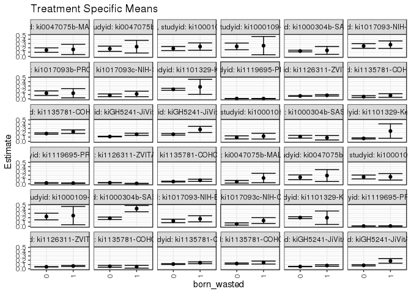

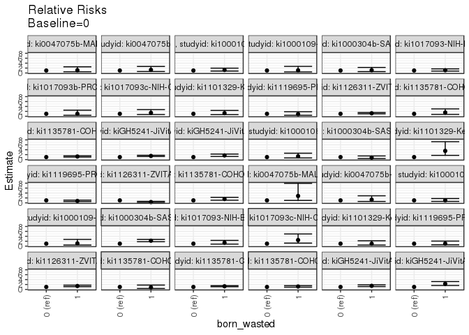

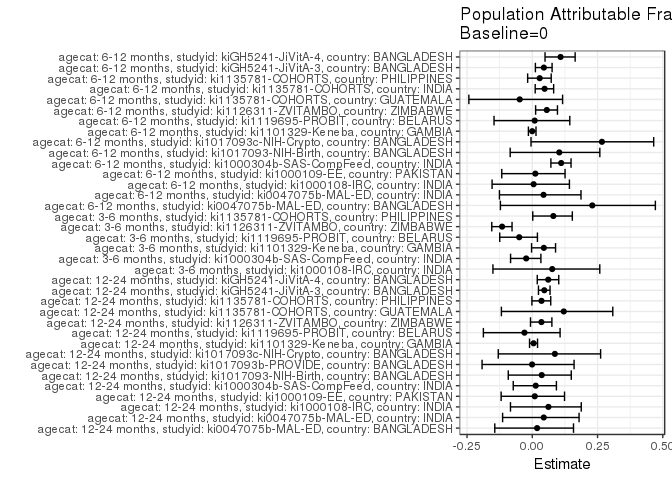

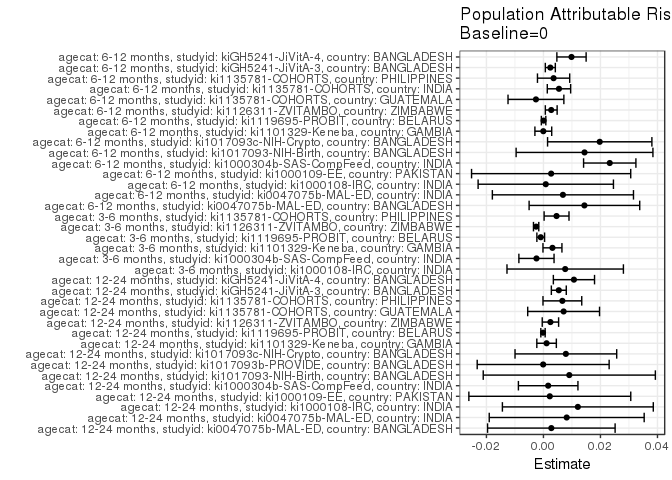

## Results Table

### Parameter: TSM

| agecat | studyid | country | intervention_level | baseline_level | estimate | ci_lower | ci_upper |
| --- | --- | --- | --- | --- | --- | --- | --- |
| 3-6 months | ki1000108-IRC | INDIA | 0 | NA | 0.0923695 | 0.0563525 | 0.1283864 |
| 3-6 months | ki1000108-IRC | INDIA | 1 | NA | 0.1208791 | 0.0538032 | 0.1879551 |
| 3-6 months | ki1000304b-SAS-CompFeed | INDIA | 0 | NA | 0.1067961 | 0.0747761 | 0.1388161 |
| 3-6 months | ki1000304b-SAS-CompFeed | INDIA | 1 | NA | 0.0833333 | 0.0315802 | 0.1350865 |
| 3-6 months | ki1101329-Keneba | GAMBIA | 0 | NA | 0.0682159 | 0.0546818 | 0.0817500 |
| 3-6 months | ki1101329-Keneba | GAMBIA | 1 | NA | 0.2400000 | 0.0725249 | 0.4074751 |
| 3-6 months | ki1119695-PROBIT | BELARUS | 0 | NA | 0.0199546 | 0.0155825 | 0.0243268 |
| 3-6 months | ki1119695-PROBIT | BELARUS | 1 | NA | 0.0154011 | 0.0094518 | 0.0213505 |
| 3-6 months | ki1126311-ZVITAMBO | ZIMBABWE | 0 | NA | 0.0247490 | 0.0211276 | 0.0283703 |
| 3-6 months | ki1126311-ZVITAMBO | ZIMBABWE | 1 | NA | 0.0078802 | 0.0030151 | 0.0127454 |
| 3-6 months | ki1135781-COHORTS | PHILIPPINES | 0 | NA | 0.0523746 | 0.0431738 | 0.0615755 |
| 3-6 months | ki1135781-COHORTS | PHILIPPINES | 1 | NA | 0.0819277 | 0.0555365 | 0.1083189 |
| 6-12 months | ki0047075b-MAL-ED | BANGLADESH | 0 | NA | 0.0481283 | 0.0173824 | 0.0788743 |
| 6-12 months | ki0047075b-MAL-ED | BANGLADESH | 1 | NA | 0.1351351 | 0.0247331 | 0.2455372 |
| 6-12 months | ki0047075b-MAL-ED | INDIA | 0 | NA | 0.1518987 | 0.0957846 | 0.2080129 |
| 6-12 months | ki0047075b-MAL-ED | INDIA | 1 | NA | 0.1935484 | 0.0541033 | 0.3329935 |
| 6-12 months | ki1000108-IRC | INDIA | 0 | NA | 0.1600000 | 0.1144893 | 0.2055107 |
| 6-12 months | ki1000108-IRC | INDIA | 1 | NA | 0.1630435 | 0.0874485 | 0.2386385 |
| 6-12 months | ki1000109-EE | PAKISTAN | 0 | NA | 0.2280702 | 0.1507495 | 0.3053909 |
| 6-12 months | ki1000109-EE | PAKISTAN | 1 | NA | 0.2500000 | 0.0370069 | 0.4629931 |
| 6-12 months | ki1000304b-SAS-CompFeed | INDIA | 0 | NA | 0.1867995 | 0.1580626 | 0.2155364 |
| 6-12 months | ki1000304b-SAS-CompFeed | INDIA | 1 | NA | 0.4130435 | 0.3395973 | 0.4864897 |
| 6-12 months | ki1017093-NIH-Birth | BANGLADESH | 0 | NA | 0.1250000 | 0.0850526 | 0.1649474 |
| 6-12 months | ki1017093-NIH-Birth | BANGLADESH | 1 | NA | 0.1743119 | 0.1029955 | 0.2456283 |
| 6-12 months | ki1017093c-NIH-Crypto | BANGLADESH | 0 | NA | 0.0542373 | 0.0283592 | 0.0801154 |
| 6-12 months | ki1017093c-NIH-Crypto | BANGLADESH | 1 | NA | 0.1340206 | 0.0661383 | 0.2019029 |
| 6-12 months | ki1101329-Keneba | GAMBIA | 0 | NA | 0.2025797 | 0.1808730 | 0.2242864 |
| 6-12 months | ki1101329-Keneba | GAMBIA | 1 | NA | 0.2000000 | 0.0431445 | 0.3568555 |
| 6-12 months | ki1119695-PROBIT | BELARUS | 0 | NA | 0.0053294 | 0.0038269 | 0.0068320 |
| 6-12 months | ki1119695-PROBIT | BELARUS | 1 | NA | 0.0055652 | 0.0016230 | 0.0095074 |
| 6-12 months | ki1126311-ZVITAMBO | ZIMBABWE | 0 | NA | 0.0464733 | 0.0418302 | 0.0511165 |
| 6-12 months | ki1126311-ZVITAMBO | ZIMBABWE | 1 | NA | 0.0644933 | 0.0516762 | 0.0773103 |
| 6-12 months | ki1135781-COHORTS | GUATEMALA | 0 | NA | 0.0572597 | 0.0366513 | 0.0778681 |
| 6-12 months | ki1135781-COHORTS | GUATEMALA | 1 | NA | 0.0470588 | 0.0152017 | 0.0789160 |
| 6-12 months | ki1135781-COHORTS | INDIA | 0 | NA | 0.1100840 | 0.1011916 | 0.1189764 |
| 6-12 months | ki1135781-COHORTS | INDIA | 1 | NA | 0.1409002 | 0.1195679 | 0.1622325 |
| 6-12 months | ki1135781-COHORTS | PHILIPPINES | 0 | NA | 0.1216338 | 0.1080588 | 0.1352087 |
| 6-12 months | ki1135781-COHORTS | PHILIPPINES | 1 | NA | 0.1450000 | 0.1104882 | 0.1795118 |
| 6-12 months | kiGH5241-JiVitA-3 | BANGLADESH | 0 | NA | 0.0519403 | 0.0473281 | 0.0565525 |
| 6-12 months | kiGH5241-JiVitA-3 | BANGLADESH | 1 | NA | 0.0757042 | 0.0590271 | 0.0923814 |
| 6-12 months | kiGH5241-JiVitA-4 | BANGLADESH | 0 | NA | 0.0809426 | 0.0667385 | 0.0951467 |
| 6-12 months | kiGH5241-JiVitA-4 | BANGLADESH | 1 | NA | 0.1835749 | 0.1302764 | 0.2368733 |
| 12-24 months | ki0047075b-MAL-ED | BANGLADESH | 0 | NA | 0.1460674 | 0.0940632 | 0.1980717 |
| 12-24 months | ki0047075b-MAL-ED | BANGLADESH | 1 | NA | 0.1621622 | 0.0431163 | 0.2812080 |
| 12-24 months | ki0047075b-MAL-ED | INDIA | 0 | NA | 0.1776316 | 0.1167046 | 0.2385585 |
| 12-24 months | ki0047075b-MAL-ED | INDIA | 1 | NA | 0.2258065 | 0.0782188 | 0.3733941 |
| 12-24 months | ki1000108-IRC | INDIA | 0 | NA | 0.1832669 | 0.1353347 | 0.2311991 |
| 12-24 months | ki1000108-IRC | INDIA | 1 | NA | 0.2282609 | 0.1423715 | 0.3141502 |
| 12-24 months | ki1000109-EE | PAKISTAN | 0 | NA | 0.2321429 | 0.1536446 | 0.3106411 |
| 12-24 months | ki1000109-EE | PAKISTAN | 1 | NA | 0.2500000 | 0.0369940 | 0.4630060 |
| 12-24 months | ki1000304b-SAS-CompFeed | INDIA | 0 | NA | 0.1241997 | 0.1054745 | 0.1429250 |
| 12-24 months | ki1000304b-SAS-CompFeed | INDIA | 1 | NA | 0.1397849 | 0.0484819 | 0.2310880 |
| 12-24 months | ki1017093-NIH-Birth | BANGLADESH | 0 | NA | 0.2416667 | 0.1874263 | 0.2959070 |
| 12-24 months | ki1017093-NIH-Birth | BANGLADESH | 1 | NA | 0.2727273 | 0.1848685 | 0.3605860 |
| 12-24 months | ki1017093b-PROVIDE | BANGLADESH | 0 | NA | 0.1320755 | 0.0793152 | 0.1848357 |
| 12-24 months | ki1017093b-PROVIDE | BANGLADESH | 1 | NA | 0.1315789 | 0.0238283 | 0.2393296 |
| 12-24 months | ki1017093c-NIH-Crypto | BANGLADESH | 0 | NA | 0.0830450 | 0.0511887 | 0.1149012 |
| 12-24 months | ki1017093c-NIH-Crypto | BANGLADESH | 1 | NA | 0.1145833 | 0.0507846 | 0.1783820 |
| 12-24 months | ki1101329-Keneba | GAMBIA | 0 | NA | 0.2224824 | 0.1996978 | 0.2452671 |
| 12-24 months | ki1101329-Keneba | GAMBIA | 1 | NA | 0.2800000 | 0.1039282 | 0.4560718 |
| 12-24 months | ki1119695-PROBIT | BELARUS | 0 | NA | 0.0053835 | 0.0029485 | 0.0078184 |
| 12-24 months | ki1119695-PROBIT | BELARUS | 1 | NA | 0.0046346 | 0.0009143 | 0.0083548 |
| 12-24 months | ki1126311-ZVITAMBO | ZIMBABWE | 0 | NA | 0.0674956 | 0.0609418 | 0.0740493 |
| 12-24 months | ki1126311-ZVITAMBO | ZIMBABWE | 1 | NA | 0.0824275 | 0.0662038 | 0.0986513 |
| 12-24 months | ki1135781-COHORTS | GUATEMALA | 0 | NA | 0.0516432 | 0.0306097 | 0.0726767 |
| 12-24 months | ki1135781-COHORTS | GUATEMALA | 1 | NA | 0.0784314 | 0.0357944 | 0.1210684 |
| 12-24 months | ki1135781-COHORTS | PHILIPPINES | 0 | NA | 0.1815242 | 0.1652847 | 0.1977638 |
| 12-24 months | ki1135781-COHORTS | PHILIPPINES | 1 | NA | 0.2253886 | 0.1836971 | 0.2670801 |
| 12-24 months | kiGH5241-JiVitA-3 | BANGLADESH | 0 | NA | 0.1115996 | 0.1045688 | 0.1186304 |
| 12-24 months | kiGH5241-JiVitA-3 | BANGLADESH | 1 | NA | 0.1643564 | 0.1395003 | 0.1892126 |
| 12-24 months | kiGH5241-JiVitA-4 | BANGLADESH | 0 | NA | 0.1644191 | 0.1452398 | 0.1835983 |
| 12-24 months | kiGH5241-JiVitA-4 | BANGLADESH | 1 | NA | 0.2772277 | 0.2052906 | 0.3491648 |

### Parameter: E(Y)

| agecat | studyid | country | intervention_level | baseline_level | estimate | ci_lower | ci_upper |
| --- | --- | --- | --- | --- | --- | --- | --- |
| 3-6 months | ki1000108-IRC | INDIA | NA | NA | 0.1000000 | 0.0680648 | 0.1319352 |
| 3-6 months | ki1000304b-SAS-CompFeed | INDIA | NA | NA | 0.1043478 | 0.0742151 | 0.1344806 |
| 3-6 months | ki1101329-Keneba | GAMBIA | NA | NA | 0.0713760 | 0.0576831 | 0.0850689 |
| 3-6 months | ki1119695-PROBIT | BELARUS | NA | NA | 0.0190034 | 0.0148301 | 0.0231768 |
| 3-6 months | ki1126311-ZVITAMBO | ZIMBABWE | NA | NA | 0.0221823 | 0.0190213 | 0.0253432 |
| 3-6 months | ki1135781-COHORTS | PHILIPPINES | NA | NA | 0.0569715 | 0.0481747 | 0.0657684 |
| 6-12 months | ki0047075b-MAL-ED | BANGLADESH | NA | NA | 0.0625000 | 0.0307297 | 0.0942703 |
| 6-12 months | ki0047075b-MAL-ED | INDIA | NA | NA | 0.1587302 | 0.1064946 | 0.2109658 |
| 6-12 months | ki1000108-IRC | INDIA | NA | NA | 0.1608187 | 0.1218275 | 0.1998100 |
| 6-12 months | ki1000109-EE | PAKISTAN | NA | NA | 0.2307692 | 0.1580632 | 0.3034753 |
| 6-12 months | ki1000304b-SAS-CompFeed | INDIA | NA | NA | 0.2100559 | 0.1780909 | 0.2420208 |
| 6-12 months | ki1017093-NIH-Birth | BANGLADESH | NA | NA | 0.1394102 | 0.1042119 | 0.1746085 |
| 6-12 months | ki1017093c-NIH-Crypto | BANGLADESH | NA | NA | 0.0739796 | 0.0480362 | 0.0999229 |
| 6-12 months | ki1101329-Keneba | GAMBIA | NA | NA | 0.2025316 | 0.1810298 | 0.2240335 |
| 6-12 months | ki1119695-PROBIT | BELARUS | NA | NA | 0.0053787 | 0.0037427 | 0.0070147 |
| 6-12 months | ki1126311-ZVITAMBO | ZIMBABWE | NA | NA | 0.0492050 | 0.0448107 | 0.0535993 |
| 6-12 months | ki1135781-COHORTS | GUATEMALA | NA | NA | 0.0546282 | 0.0372644 | 0.0719920 |
| 6-12 months | ki1135781-COHORTS | INDIA | NA | NA | 0.1155310 | 0.1072908 | 0.1237711 |
| 6-12 months | ki1135781-COHORTS | PHILIPPINES | NA | NA | 0.1251903 | 0.1125353 | 0.1378452 |
| 6-12 months | kiGH5241-JiVitA-3 | BANGLADESH | NA | NA | 0.0543537 | 0.0498489 | 0.0588584 |
| 6-12 months | kiGH5241-JiVitA-4 | BANGLADESH | NA | NA | 0.0907828 | 0.0771434 | 0.1044222 |
| 12-24 months | ki0047075b-MAL-ED | BANGLADESH | NA | NA | 0.1488372 | 0.1011498 | 0.1965246 |
| 12-24 months | ki0047075b-MAL-ED | INDIA | NA | NA | 0.1857923 | 0.1292864 | 0.2422983 |
| 12-24 months | ki1000108-IRC | INDIA | NA | NA | 0.1953353 | 0.1533175 | 0.2373530 |
| 12-24 months | ki1000109-EE | PAKISTAN | NA | NA | 0.2343750 | 0.1607017 | 0.3080483 |
| 12-24 months | ki1000304b-SAS-CompFeed | INDIA | NA | NA | 0.1258581 | 0.1080384 | 0.1436778 |
| 12-24 months | ki1017093-NIH-Birth | BANGLADESH | NA | NA | 0.2507375 | 0.2045295 | 0.2969454 |
| 12-24 months | ki1017093b-PROVIDE | BANGLADESH | NA | NA | 0.1319797 | 0.0845949 | 0.1793644 |
| 12-24 months | ki1017093c-NIH-Crypto | BANGLADESH | NA | NA | 0.0909091 | 0.0621557 | 0.1196625 |
| 12-24 months | ki1101329-Keneba | GAMBIA | NA | NA | 0.2235835 | 0.2009782 | 0.2461887 |
| 12-24 months | ki1119695-PROBIT | BELARUS | NA | NA | 0.0052266 | 0.0028868 | 0.0075664 |
| 12-24 months | ki1126311-ZVITAMBO | ZIMBABWE | NA | NA | 0.0699436 | 0.0638514 | 0.0760357 |
| 12-24 months | ki1135781-COHORTS | GUATEMALA | NA | NA | 0.0587219 | 0.0395554 | 0.0778885 |
| 12-24 months | ki1135781-COHORTS | PHILIPPINES | NA | NA | 0.1881615 | 0.1729918 | 0.2033312 |
| 12-24 months | kiGH5241-JiVitA-3 | BANGLADESH | NA | NA | 0.1169922 | 0.1100927 | 0.1238917 |
| 12-24 months | kiGH5241-JiVitA-4 | BANGLADESH | NA | NA | 0.1751174 | 0.1566212 | 0.1936135 |

### Parameter: RR

| agecat | studyid | country | intervention_level | baseline_level | estimate | ci_lower | ci_upper |
| --- | --- | --- | --- | --- | --- | --- | --- |
| 3-6 months | ki1000108-IRC | INDIA | 0 | 0 | 1.0000000 | 1.0000000 | 1.0000000 |
| 3-6 months | ki1000108-IRC | INDIA | 1 | 0 | 1.3086479 | 0.6641779 | 2.5784648 |
| 3-6 months | ki1000304b-SAS-CompFeed | INDIA | 0 | 0 | 1.0000000 | 1.0000000 | 1.0000000 |
| 3-6 months | ki1000304b-SAS-CompFeed | INDIA | 1 | 0 | 0.7803030 | 0.4132212 | 1.4734791 |
| 3-6 months | ki1101329-Keneba | GAMBIA | 0 | 0 | 1.0000000 | 1.0000000 | 1.0000000 |
| 3-6 months | ki1101329-Keneba | GAMBIA | 1 | 0 | 3.5182418 | 1.7031708 | 7.2676357 |
| 3-6 months | ki1119695-PROBIT | BELARUS | 0 | 0 | 1.0000000 | 1.0000000 | 1.0000000 |
| 3-6 months | ki1119695-PROBIT | BELARUS | 1 | 0 | 0.7718093 | 0.5314532 | 1.1208692 |
| 3-6 months | ki1126311-ZVITAMBO | ZIMBABWE | 0 | 0 | 1.0000000 | 1.0000000 | 1.0000000 |
| 3-6 months | ki1126311-ZVITAMBO | ZIMBABWE | 1 | 0 | 0.3184059 | 0.1688210 | 0.6005315 |
| 3-6 months | ki1135781-COHORTS | PHILIPPINES | 0 | 0 | 1.0000000 | 1.0000000 | 1.0000000 |
| 3-6 months | ki1135781-COHORTS | PHILIPPINES | 1 | 0 | 1.5642638 | 1.0838276 | 2.2576666 |
| 6-12 months | ki0047075b-MAL-ED | BANGLADESH | 0 | 0 | 1.0000000 | 1.0000000 | 1.0000000 |
| 6-12 months | ki0047075b-MAL-ED | BANGLADESH | 1 | 0 | 2.8078078 | 0.9953247 | 7.9208169 |
| 6-12 months | ki0047075b-MAL-ED | INDIA | 0 | 0 | 1.0000000 | 1.0000000 | 1.0000000 |
| 6-12 months | ki0047075b-MAL-ED | INDIA | 1 | 0 | 1.2741935 | 0.5670308 | 2.8632821 |
| 6-12 months | ki1000108-IRC | INDIA | 0 | 0 | 1.0000000 | 1.0000000 | 1.0000000 |
| 6-12 months | ki1000108-IRC | INDIA | 1 | 0 | 1.0190217 | 0.5914941 | 1.7555634 |
| 6-12 months | ki1000109-EE | PAKISTAN | 0 | 0 | 1.0000000 | 1.0000000 | 1.0000000 |
| 6-12 months | ki1000109-EE | PAKISTAN | 1 | 0 | 1.0961538 | 0.4381737 | 2.7421848 |
| 6-12 months | ki1000304b-SAS-CompFeed | INDIA | 0 | 0 | 1.0000000 | 1.0000000 | 1.0000000 |
| 6-12 months | ki1000304b-SAS-CompFeed | INDIA | 1 | 0 | 2.2111594 | 1.7921937 | 2.7280679 |
| 6-12 months | ki1017093-NIH-Birth | BANGLADESH | 0 | 0 | 1.0000000 | 1.0000000 | 1.0000000 |
| 6-12 months | ki1017093-NIH-Birth | BANGLADESH | 1 | 0 | 1.3944954 | 0.8297596 | 2.3435915 |
| 6-12 months | ki1017093c-NIH-Crypto | BANGLADESH | 0 | 0 | 1.0000000 | 1.0000000 | 1.0000000 |
| 6-12 months | ki1017093c-NIH-Crypto | BANGLADESH | 1 | 0 | 2.4710052 | 1.2321753 | 4.9553552 |
| 6-12 months | ki1101329-Keneba | GAMBIA | 0 | 0 | 1.0000000 | 1.0000000 | 1.0000000 |
| 6-12 months | ki1101329-Keneba | GAMBIA | 1 | 0 | 0.9872659 | 0.4473655 | 2.1787421 |
| 6-12 months | ki1119695-PROBIT | BELARUS | 0 | 0 | 1.0000000 | 1.0000000 | 1.0000000 |
| 6-12 months | ki1119695-PROBIT | BELARUS | 1 | 0 | 1.0442459 | 0.5298253 | 2.0581302 |
| 6-12 months | ki1126311-ZVITAMBO | ZIMBABWE | 0 | 0 | 1.0000000 | 1.0000000 | 1.0000000 |
| 6-12 months | ki1126311-ZVITAMBO | ZIMBABWE | 1 | 0 | 1.3877475 | 1.1109847 | 1.7334559 |
| 6-12 months | ki1135781-COHORTS | GUATEMALA | 0 | 0 | 1.0000000 | 1.0000000 | 1.0000000 |
| 6-12 months | ki1135781-COHORTS | GUATEMALA | 1 | 0 | 0.8218488 | 0.3817876 | 1.7691393 |
| 6-12 months | ki1135781-COHORTS | INDIA | 0 | 0 | 1.0000000 | 1.0000000 | 1.0000000 |
| 6-12 months | ki1135781-COHORTS | INDIA | 1 | 0 | 1.2799331 | 1.0781064 | 1.5195427 |
| 6-12 months | ki1135781-COHORTS | PHILIPPINES | 0 | 0 | 1.0000000 | 1.0000000 | 1.0000000 |
| 6-12 months | ki1135781-COHORTS | PHILIPPINES | 1 | 0 | 1.1921033 | 0.9165302 | 1.5505331 |
| 6-12 months | kiGH5241-JiVitA-3 | BANGLADESH | 0 | 0 | 1.0000000 | 1.0000000 | 1.0000000 |
| 6-12 months | kiGH5241-JiVitA-3 | BANGLADESH | 1 | 0 | 1.4575239 | 1.1505934 | 1.8463307 |
| 6-12 months | kiGH5241-JiVitA-4 | BANGLADESH | 0 | 0 | 1.0000000 | 1.0000000 | 1.0000000 |
| 6-12 months | kiGH5241-JiVitA-4 | BANGLADESH | 1 | 0 | 2.2679631 | 1.6085462 | 3.1977051 |
| 12-24 months | ki0047075b-MAL-ED | BANGLADESH | 0 | 0 | 1.0000000 | 1.0000000 | 1.0000000 |
| 12-24 months | ki0047075b-MAL-ED | BANGLADESH | 1 | 0 | 1.1101871 | 0.4909733 | 2.5103514 |
| 12-24 months | ki0047075b-MAL-ED | INDIA | 0 | 0 | 1.0000000 | 1.0000000 | 1.0000000 |
| 12-24 months | ki0047075b-MAL-ED | INDIA | 1 | 0 | 1.2712067 | 0.6076429 | 2.6594016 |
| 12-24 months | ki1000108-IRC | INDIA | 0 | 0 | 1.0000000 | 1.0000000 | 1.0000000 |
| 12-24 months | ki1000108-IRC | INDIA | 1 | 0 | 1.2455104 | 0.7876508 | 1.9695226 |
| 12-24 months | ki1000109-EE | PAKISTAN | 0 | 0 | 1.0000000 | 1.0000000 | 1.0000000 |
| 12-24 months | ki1000109-EE | PAKISTAN | 1 | 0 | 1.0769231 | 0.4306049 | 2.6933350 |
| 12-24 months | ki1000304b-SAS-CompFeed | INDIA | 0 | 0 | 1.0000000 | 1.0000000 | 1.0000000 |
| 12-24 months | ki1000304b-SAS-CompFeed | INDIA | 1 | 0 | 1.1254850 | 0.5613509 | 2.2565501 |
| 12-24 months | ki1017093-NIH-Birth | BANGLADESH | 0 | 0 | 1.0000000 | 1.0000000 | 1.0000000 |
| 12-24 months | ki1017093-NIH-Birth | BANGLADESH | 1 | 0 | 1.1285266 | 0.7620737 | 1.6711932 |
| 12-24 months | ki1017093b-PROVIDE | BANGLADESH | 0 | 0 | 1.0000000 | 1.0000000 | 1.0000000 |
| 12-24 months | ki1017093b-PROVIDE | BANGLADESH | 1 | 0 | 0.9962406 | 0.4005529 | 2.4778132 |
| 12-24 months | ki1017093c-NIH-Crypto | BANGLADESH | 0 | 0 | 1.0000000 | 1.0000000 | 1.0000000 |
| 12-24 months | ki1017093c-NIH-Crypto | BANGLADESH | 1 | 0 | 1.3797743 | 0.7017210 | 2.7130113 |
| 12-24 months | ki1101329-Keneba | GAMBIA | 0 | 0 | 1.0000000 | 1.0000000 | 1.0000000 |
| 12-24 months | ki1101329-Keneba | GAMBIA | 1 | 0 | 1.2585263 | 0.6655304 | 2.3798891 |
| 12-24 months | ki1119695-PROBIT | BELARUS | 0 | 0 | 1.0000000 | 1.0000000 | 1.0000000 |
| 12-24 months | ki1119695-PROBIT | BELARUS | 1 | 0 | 0.8608938 | 0.4023790 | 1.8418903 |
| 12-24 months | ki1126311-ZVITAMBO | ZIMBABWE | 0 | 0 | 1.0000000 | 1.0000000 | 1.0000000 |
| 12-24 months | ki1126311-ZVITAMBO | ZIMBABWE | 1 | 0 | 1.2212290 | 0.9805763 | 1.5209426 |
| 12-24 months | ki1135781-COHORTS | GUATEMALA | 0 | 0 | 1.0000000 | 1.0000000 | 1.0000000 |
| 12-24 months | ki1135781-COHORTS | GUATEMALA | 1 | 0 | 1.5187166 | 0.7699710 | 2.9955676 |
| 12-24 months | ki1135781-COHORTS | PHILIPPINES | 0 | 0 | 1.0000000 | 1.0000000 | 1.0000000 |
| 12-24 months | ki1135781-COHORTS | PHILIPPINES | 1 | 0 | 1.2416446 | 1.0110229 | 1.5248728 |
| 12-24 months | kiGH5241-JiVitA-3 | BANGLADESH | 0 | 0 | 1.0000000 | 1.0000000 | 1.0000000 |
| 12-24 months | kiGH5241-JiVitA-3 | BANGLADESH | 1 | 0 | 1.4727333 | 1.2528964 | 1.7311434 |
| 12-24 months | kiGH5241-JiVitA-4 | BANGLADESH | 0 | 0 | 1.0000000 | 1.0000000 | 1.0000000 |
| 12-24 months | kiGH5241-JiVitA-4 | BANGLADESH | 1 | 0 | 1.6861043 | 1.2647550 | 2.2478248 |

### Parameter: PAR

| agecat | studyid | country | intervention_level | baseline_level | estimate | ci_lower | ci_upper |
| --- | --- | --- | --- | --- | --- | --- | --- |
| 3-6 months | ki1000108-IRC | INDIA | 0 | NA | 0.0076305 | -0.0127908 | 0.0280518 |
| 3-6 months | ki1000304b-SAS-CompFeed | INDIA | 0 | NA | -0.0024483 | -0.0086158 | 0.0037192 |
| 3-6 months | ki1101329-Keneba | GAMBIA | 0 | NA | 0.0031601 | -0.0001657 | 0.0064859 |
| 3-6 months | ki1119695-PROBIT | BELARUS | 0 | NA | -0.0009512 | -0.0023037 | 0.0004014 |
| 3-6 months | ki1126311-ZVITAMBO | ZIMBABWE | 0 | NA | -0.0025667 | -0.0034987 | -0.0016348 |
| 3-6 months | ki1135781-COHORTS | PHILIPPINES | 0 | NA | 0.0045969 | 0.0002305 | 0.0089633 |
| 6-12 months | ki0047075b-MAL-ED | BANGLADESH | 0 | NA | 0.0143717 | -0.0050275 | 0.0337708 |
| 6-12 months | ki0047075b-MAL-ED | INDIA | 0 | NA | 0.0068314 | -0.0179213 | 0.0315842 |
| 6-12 months | ki1000108-IRC | INDIA | 0 | NA | 0.0008187 | -0.0229181 | 0.0245555 |
| 6-12 months | ki1000109-EE | PAKISTAN | 0 | NA | 0.0026991 | -0.0252171 | 0.0306152 |
| 6-12 months | ki1000304b-SAS-CompFeed | INDIA | 0 | NA | 0.0232564 | 0.0140791 | 0.0324336 |
| 6-12 months | ki1017093-NIH-Birth | BANGLADESH | 0 | NA | 0.0144102 | -0.0095855 | 0.0384058 |
| 6-12 months | ki1017093c-NIH-Crypto | BANGLADESH | 0 | NA | 0.0197423 | 0.0014447 | 0.0380399 |
| 6-12 months | ki1101329-Keneba | GAMBIA | 0 | NA | -0.0000480 | -0.0029958 | 0.0028997 |
| 6-12 months | ki1119695-PROBIT | BELARUS | 0 | NA | 0.0000493 | -0.0007346 | 0.0008332 |
| 6-12 months | ki1126311-ZVITAMBO | ZIMBABWE | 0 | NA | 0.0027316 | 0.0006610 | 0.0048023 |
| 6-12 months | ki1135781-COHORTS | GUATEMALA | 0 | NA | -0.0026315 | -0.0124252 | 0.0071622 |
| 6-12 months | ki1135781-COHORTS | INDIA | 0 | NA | 0.0054469 | 0.0013506 | 0.0095432 |
| 6-12 months | ki1135781-COHORTS | PHILIPPINES | 0 | NA | 0.0035565 | -0.0020973 | 0.0092103 |
| 6-12 months | kiGH5241-JiVitA-3 | BANGLADESH | 0 | NA | 0.0024134 | 0.0006588 | 0.0041679 |
| 6-12 months | kiGH5241-JiVitA-4 | BANGLADESH | 0 | NA | 0.0098401 | 0.0047072 | 0.0149731 |
| 12-24 months | ki0047075b-MAL-ED | BANGLADESH | 0 | NA | 0.0027698 | -0.0196015 | 0.0251410 |
| 12-24 months | ki0047075b-MAL-ED | INDIA | 0 | NA | 0.0081608 | -0.0190141 | 0.0353356 |
| 12-24 months | ki1000108-IRC | INDIA | 0 | NA | 0.0120683 | -0.0143981 | 0.0385348 |
| 12-24 months | ki1000109-EE | PAKISTAN | 0 | NA | 0.0022321 | -0.0261627 | 0.0306270 |
| 12-24 months | ki1000304b-SAS-CompFeed | INDIA | 0 | NA | 0.0016584 | -0.0087838 | 0.0121006 |
| 12-24 months | ki1017093-NIH-Birth | BANGLADESH | 0 | NA | 0.0090708 | -0.0211203 | 0.0392619 |
| 12-24 months | ki1017093b-PROVIDE | BANGLADESH | 0 | NA | -0.0000958 | -0.0232380 | 0.0230465 |
| 12-24 months | ki1017093c-NIH-Crypto | BANGLADESH | 0 | NA | 0.0078641 | -0.0099693 | 0.0256976 |
| 12-24 months | ki1101329-Keneba | GAMBIA | 0 | NA | 0.0011010 | -0.0023243 | 0.0045264 |
| 12-24 months | ki1119695-PROBIT | BELARUS | 0 | NA | -0.0001568 | -0.0009166 | 0.0006030 |
| 12-24 months | ki1126311-ZVITAMBO | ZIMBABWE | 0 | NA | 0.0024480 | -0.0004236 | 0.0053197 |
| 12-24 months | ki1135781-COHORTS | GUATEMALA | 0 | NA | 0.0070787 | -0.0055212 | 0.0196787 |
| 12-24 months | ki1135781-COHORTS | PHILIPPINES | 0 | NA | 0.0066373 | -0.0001603 | 0.0134348 |
| 12-24 months | kiGH5241-JiVitA-3 | BANGLADESH | 0 | NA | 0.0053926 | 0.0027749 | 0.0080104 |
| 12-24 months | kiGH5241-JiVitA-4 | BANGLADESH | 0 | NA | 0.0106983 | 0.0034761 | 0.0179205 |

### Parameter: PAF

| agecat | studyid | country | intervention_level | baseline_level | estimate | ci_lower | ci_upper |
| --- | --- | --- | --- | --- | --- | --- | --- |
| 3-6 months | ki1000108-IRC | INDIA | 0 | NA | 0.0763052 | -0.1507973 | 0.2585905 |
| 3-6 months | ki1000304b-SAS-CompFeed | INDIA | 0 | NA | -0.0234628 | -0.0831795 | 0.0329617 |
| 3-6 months | ki1101329-Keneba | GAMBIA | 0 | NA | 0.0442743 | -0.0027778 | 0.0891185 |
| 3-6 months | ki1119695-PROBIT | BELARUS | 0 | NA | -0.0500522 | -0.1247303 | 0.0196676 |
| 3-6 months | ki1126311-ZVITAMBO | ZIMBABWE | 0 | NA | -0.1157105 | -0.1552139 | -0.0775580 |
| 3-6 months | ki1135781-COHORTS | PHILIPPINES | 0 | NA | 0.0806877 | 0.0017449 | 0.1533877 |
| 6-12 months | ki0047075b-MAL-ED | BANGLADESH | 0 | NA | 0.2299465 | -0.1221620 | 0.4715715 |
| 6-12 months | ki0047075b-MAL-ED | INDIA | 0 | NA | 0.0430380 | -0.1258451 | 0.1865877 |
| 6-12 months | ki1000108-IRC | INDIA | 0 | NA | 0.0050909 | -0.1540158 | 0.1422612 |
| 6-12 months | ki1000109-EE | PAKISTAN | 0 | NA | 0.0116959 | -0.1169631 | 0.1255351 |
| 6-12 months | ki1000304b-SAS-CompFeed | INDIA | 0 | NA | 0.1107151 | 0.0712699 | 0.1484851 |
| 6-12 months | ki1017093-NIH-Birth | BANGLADESH | 0 | NA | 0.1033654 | -0.0846815 | 0.2588113 |
| 6-12 months | ki1017093c-NIH-Crypto | BANGLADESH | 0 | NA | 0.2668615 | -0.0049137 | 0.4651361 |
| 6-12 months | ki1101329-Keneba | GAMBIA | 0 | NA | -0.0002371 | -0.0148981 | 0.0142121 |
| 6-12 months | ki1119695-PROBIT | BELARUS | 0 | NA | 0.0091613 | -0.1465732 | 0.1437431 |
| 6-12 months | ki1126311-ZVITAMBO | ZIMBABWE | 0 | NA | 0.0555155 | 0.0127579 | 0.0964214 |
| 6-12 months | ki1135781-COHORTS | GUATEMALA | 0 | NA | -0.0481709 | -0.2430114 | 0.1161286 |
| 6-12 months | ki1135781-COHORTS | INDIA | 0 | NA | 0.0471469 | 0.0111471 | 0.0818361 |
| 6-12 months | ki1135781-COHORTS | PHILIPPINES | 0 | NA | 0.0284088 | -0.0177499 | 0.0724741 |
| 6-12 months | kiGH5241-JiVitA-3 | BANGLADESH | 0 | NA | 0.0444010 | 0.0118588 | 0.0758716 |
| 6-12 months | kiGH5241-JiVitA-4 | BANGLADESH | 0 | NA | 0.1083922 | 0.0488486 | 0.1642083 |
| 12-24 months | ki0047075b-MAL-ED | BANGLADESH | 0 | NA | 0.0186096 | -0.1437279 | 0.1579053 |
| 12-24 months | ki0047075b-MAL-ED | INDIA | 0 | NA | 0.0439241 | -0.1137207 | 0.1792547 |
| 12-24 months | ki1000108-IRC | INDIA | 0 | NA | 0.0617827 | -0.0835711 | 0.1876383 |
| 12-24 months | ki1000109-EE | PAKISTAN | 0 | NA | 0.0095238 | -0.1193320 | 0.1235459 |
| 12-24 months | ki1000304b-SAS-CompFeed | INDIA | 0 | NA | 0.0131766 | -0.0729868 | 0.0924209 |
| 12-24 months | ki1017093-NIH-Birth | BANGLADESH | 0 | NA | 0.0361765 | -0.0920029 | 0.1493102 |
| 12-24 months | ki1017093b-PROVIDE | BANGLADESH | 0 | NA | -0.0007257 | -0.1923729 | 0.1601185 |
| 12-24 months | ki1017093c-NIH-Crypto | BANGLADESH | 0 | NA | 0.0865052 | -0.1303789 | 0.2617761 |
| 12-24 months | ki1101329-Keneba | GAMBIA | 0 | NA | 0.0049244 | -0.0105108 | 0.0201239 |
| 12-24 months | ki1119695-PROBIT | BELARUS | 0 | NA | -0.0300084 | -0.1873845 | 0.1065091 |
| 12-24 months | ki1126311-ZVITAMBO | ZIMBABWE | 0 | NA | 0.0349998 | -0.0068417 | 0.0751025 |
| 12-24 months | ki1135781-COHORTS | GUATEMALA | 0 | NA | 0.1205468 | -0.1183416 | 0.3084064 |
| 12-24 months | ki1135781-COHORTS | PHILIPPINES | 0 | NA | 0.0352742 | -0.0014727 | 0.0706729 |
| 12-24 months | kiGH5241-JiVitA-3 | BANGLADESH | 0 | NA | 0.0460938 | 0.0236728 | 0.0679998 |
| 12-24 months | kiGH5241-JiVitA-4 | BANGLADESH | 0 | NA | 0.0610921 | 0.0190703 | 0.1013137 |